# Module_8: Simple Linear Regression

Harry Smith and Caroline Ledbetter

6/27/2018

**Correlation**

You learned all about correlation coefficients in your Introductory Biostatistics class. The concepts behind assessing correlations underlie those of regression as well, so in this lab we’ll start with correlation and work our way through simple linear regression. In R, the cor() function computes Pearson correlation coefficients between two specified variables. Recall that a correlation coefficient ($\rho$, read as “rho”), ranges from -1 to 1, and measures the degree to which two variables (y and x) are linearly related (i.e., $y = \beta_0 + \beta_{1x}$). Positive correlation coefficients indicate a direct linear relationship between the variables. Negative correlation coefficients indicate inverse linear relationships, and a zero coefficient indicates no linear relationship. If the correlation coefficient is exactly 1 or -1, the two variables have a perfect linear relationship. Correlation estimates differ from linear regression – in linear regression one variable is being predicted by another, where in correlation we are measuring the strength of the linear relationship. The correlation coefficient is a measure of the strength of the linear trend relative to the variability of the data around that trend. Thus, it is dependent both on the magnitude of the trend and the magnitude of the variability in the data. There are many correlation coefficients, which are good descriptive statistic for two variables; but the most appropriate one depends on whether the variables are continuous, discrete, or ordinal. Here we’re discussing Pearson Correlation for two continuous variables.

**Note:** The correlation coefficient shows deviance from linear relationships. A correlation of 0 does not mean that the two variables are not related, merely that they are not linearly related. For example, the equation $y = x^2$ gives $\rho = 0$, but x and y are related through the quadratic equation. Our estimate of  is r and we can estimate it parametrically or non-parametrically (using ranks).

**Correlation Function And Syntax**

- cor(x, use= , method= )

where :

- x = matrix or data frame
- use= specifies how missing data are treated. Options include : all.obs (assumes no missing data) ; complete.obs (listwise deletion); pairwise.complete.obs (pairwise deletion)
- method= specifies the correlation type (pearson, spearman, or kendall)

The assumptions required for a Pearson correlation coefficient are:

1. y and x joint normally distributed (interval or continuous data)
2. independence of the observations

The assumptions required for the use of the Spearman correlation coefficient are:

1. ordinal or interval scale data
2. independence of the observations

**Example 1:** This example uses data, which gives the percentage of children immunized against DPT and under age 5 mortality rates for 20 countries. The question is whether there is a linear relationship between the percentage of children who have been immunized and the mortality rate for children under 5. It is also good practice to plot the data before doing any analysis.

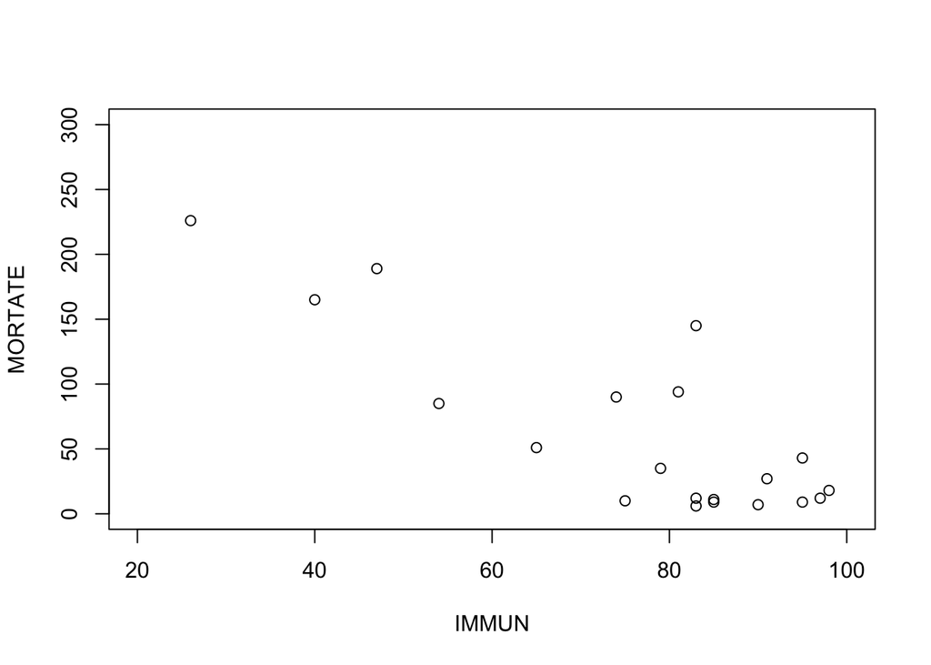

```r
#Build dataset for analysis
country <- c("BOL", "BRZ", "CAN", "CHN", "EGT", "ETH", "FIN", "FRA", "GRE",
             "IND", "ITA", "JPN", "MEX", "POL", "SEN", "TRK", "UK", "USA",
             "USR", "YGO")
immun <- c(40, 54, 85, 95, 81, 26, 90, 95, 83, 83, 85, 83,
           65, 98, 47, 74, 75, 97, 79, 91)
mortate <- c(165, 85, 9, 43, 94, 226, 7, 9, 12, 145, 11,
             6, 51, 18, 189, 90, 10, 12, 35, 27)

## Build dataframe
dptmort <- data.frame(country, immun, mortate)

## Build plot
plot(dptmort$immun,
     dptmort$mortate,
     ylab="MORTATE",
     xlab="IMMUN",
     ylim=c(0,300),
     xlim=c(20, 100))
```

**Interpretation Of The Plot:** Before interpreting the analysis, answer these questions:

1. Does there seem to be a linear relationship between mortality rate and immunization?
2. Is the relationship positive or negative?

**Correlation analysis**

```r
## cor() using Pearson method
cor(dptmort$immun, dptmort$mortate, method="pearson")
```

```
## [1] -0.8290753
```

```r
## cor() using Spearman method
cor(dptmort$immun, dptmort$mortate, method="spearman")
```

```
## [1] -0.6357473
```

```r
## cor.test() using Pearson method
cor.test(dptmort$immun, dptmort$mortate, method="pearson")
```

```
##
##  Pearson's product-moment correlation
##
## data:  dptmort$immun and dptmort$mortate
## t = -6.2909, df = 18, p-value = 6.246e-06
## alternative hypothesis: true correlation is not equal to 0
## 95 percent confidence interval:
##  -0.9302889 -0.6105578
## sample estimates:
##        cor
## -0.8290753
```

**Correlation Between All Variables In A Data Set:** Sometimes when doing exploratory data analysis one may want to see all correlations between all variables. To do this we can use matcor() function in the CCA package. This is a very useful function and can take a data frame as the primary argument. In this example, we are going to use a data set called “mm” that includes information on psychological locust of control and measures of academic standardized testing (for more information see: [here](http://www.ats.ucla.edu/stat/r/dae/canonical.htm)).

```r
## When installing the CCA package it will ask yo if you want to do a compile
# step. type 'n' for this.
#install.packages("CCA")
suppressMessages(library(CCA))
## Load data
mm <- read.csv("https://stats.idre.ucla.edu/stat/data/mmreg.csv")

## Add column names
colnames(mm) <- c("Control", "Concept", "Motivation", "Read", "Write", "Math", "Science", "Sex")

psych <- mm[, 1:3]  # select the first three variables and all rows.
acad <- mm[, 4:8]    # select variable 4 to 8 and all rows

## Get all correlations
matcor(psych, acad)
```

```
## $Xcor
##              Control   Concept Motivation
## Control    1.0000000 0.1711878  0.2451323
## Concept    0.1711878 1.0000000  0.2885707
## Motivation 0.2451323 0.2885707  1.0000000
##
## $Ycor
##                Read     Write       Math    Science         Sex
## Read     1.00000000 0.6285909  0.6792757  0.6906929 -0.04174278
## Write    0.62859089 1.0000000  0.6326664  0.5691498  0.24433183
## Math     0.67927568 0.6326664  1.0000000  0.6495261 -0.04821830
## Science  0.69069291 0.5691498  0.6495261  1.0000000 -0.13818587
## Sex     -0.04174278 0.2443318 -0.0482183 -0.1381859  1.00000000
##
## $XYcor
##              Control     Concept Motivation        Read      Write
## Control    1.0000000  0.17118778 0.24513227  0.37356505 0.35887684
## Concept    0.1711878  1.00000000 0.28857075  0.06065584 0.01944856
## Motivation 0.2451323  0.28857075 1.00000000  0.21060992 0.25424818
## Read       0.3735650  0.06065584 0.21060992  1.00000000 0.62859089
## Write      0.3588768  0.01944856 0.25424818  0.62859089 1.00000000
## Math       0.3372690  0.05359770 0.19501347  0.67927568 0.63266640
## Science    0.3246269  0.06982633 0.11566948  0.69069291 0.56914983
## Sex        0.1134108 -0.12595132 0.09810277 -0.04174278 0.24433183
##                  Math     Science         Sex
## Control     0.3372690  0.32462694  0.11341075
## Concept     0.0535977  0.06982633 -0.12595132
## Motivation  0.1950135  0.11566948  0.09810277
## Read        0.6792757  0.69069291 -0.04174278
## Write       0.6326664  0.56914983  0.24433183
## Math        1.0000000  0.64952612 -0.04821830
## Science     0.6495261  1.00000000 -0.13818587
## Sex        -0.0482183 -0.13818587  1.00000000
```

**Introduction to Linear Regression:** Linear regression is a method of finding and quantifying linear relationships between variables. For example, if you saw the graph below, you would probably note that the two variables, under age 5 mortality rate and childhood immunizations seem to be related - as childhood immunizations increase, under age 5 mortality rates decrease. But by how much? How sure are we about this relationship? Linear regression, which determines the best fitting line to the data, can answer these questions and more. However, Linear Regression always finds a best linear fit, even when the relationship is not linear, so we always need to confirm or test for a significant fit.

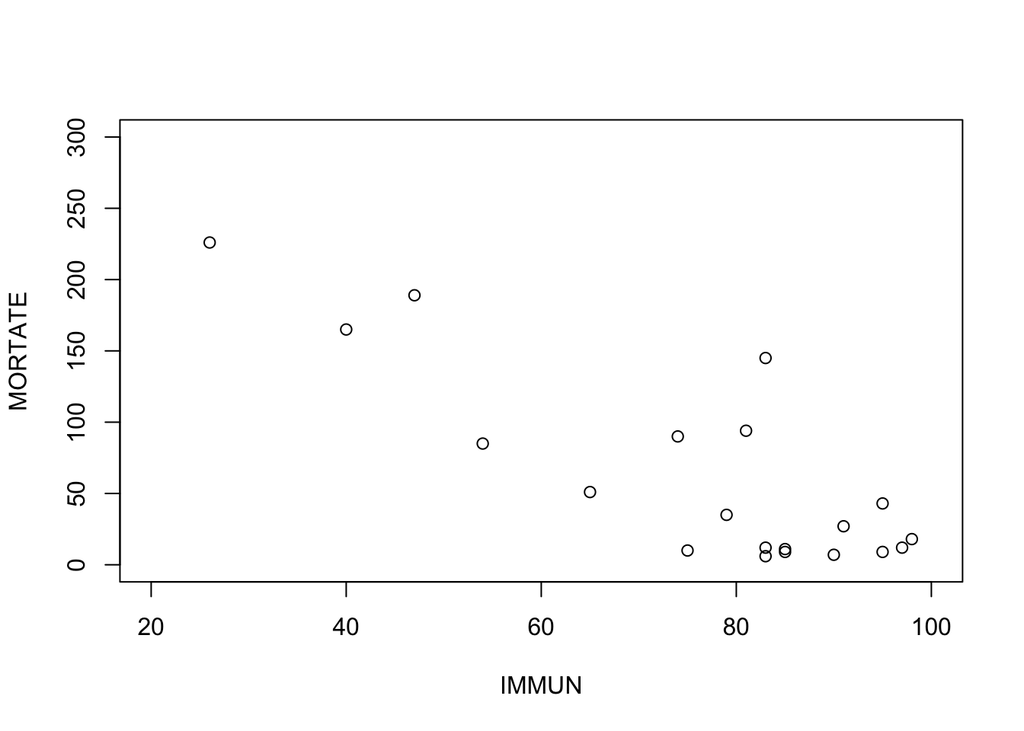

Regression analysis is versatile and can be used for many purposes, such as: inference, prediction, and adjustment of covariates. For example, in a randomized trial one may want to control for some of the variables that were difficult or impossible to ‘design out’ of the experiment. Cross-sectional and longitudinal studies often use regression methods to make inference since control of confounding is usually not possible in their designs.

**Simple Linear Regression Model:** The term simple, in simple linear regression, refers to the fact that there is only one independent variable. Other terms used for “independent variable”, include: covariate, regressor, explanatory variable, risk factor). Our model for simple linear regression is:

$y = \beta_0 + \beta_{1x}$ or dependent = intercept + slope*independent.

What sort of data can be used for linear regression? Using the model $y = \beta_0 + \beta_{1x}$, the dependent variable, y, must be continuous and the independent variable, x, can be continuous or categorical.

**Assumptions For Simple Linear Regression:**

**The lm() Function:** The lm() function is one of many procedures in R that can be used to compute a least squares regression line.

**lm() syntax**

```
lm(formula, data, subset, weights, na.action, method = "qr", model = TRUE, x = FALSE, y = FALSE, qr = TRUE, singular.ok = TRUE, contrasts = NULL, offset, ...)
```

| Option | Description |
| --- | --- |
| formula | an object of class “formula”, say y~x, which is a symbolic description of the model to be fitted. |
| data | an optional data frame or list containing the variables in the model. If not found in data, the variables are taken from environment(formula), typically the environment from which lm is called. |
| subset | an optional vector specifying a subset of observations to be used in the fitting process. |
| weights | an optional vector of weights to be used in the fitting process. Should be NULL or a numeric vector. If non-NULL, weighted least squares is used with weights that minimizing sum(w*e^2); otherwise ordi… |
| na.action | a function which indicates what should happen when the data contain NAs. The default is set by the na.action setting of options, and is na.fail if that is unset. The ‘factory-fresh’ default is na.omit… |
| method | the method to be used; for fitting, currently only method = “qr” is supported; method = “model.frame” returns the model frame (the same as with model = TRUE, see below). |
| model, x, y, qr | logicals. If TRUE the corresponding components of the fit (the model frame, the model matrix, the response, the QR decomposition) are returned. |
| singular.ok | logical. If FALSE (the default in S but not in R) a singular fit is an error. |
| contrasts | an optional list. See the contrasts.arg of model.matrix.default. |
| offset | this can be used to specify an a priori known component to be included in the linear predictor during fitting. This should be NULL or a numeric vector of length equal to the number of cases. One or mo… |

**Example Using The lm() Function:**  
This example uses the data that we looked at on the first page, with child immunizations and under age 5 mortality. We think that as immunizations increase, so under age 5 mortality decreases, and we would like to further quantify this relationship. By looking at the plot ahead of time (always a good first step!) we see that the data look linear, so using linear regression seems reasonable. If the data do NOT look linear, a nonlinear function or some nonlinear terms may be needed, such as $x^2$ or $ln(x)$ — but we will not be discussing this here.

```r
## Here we are telling R that we want to run a linear regression model with the
# mortate and immune variables.
model = lm(dptmort$mortate ~ dptmort$immun)

## To get the full output we need to use the summary() function.
summary(model)
```

```
##
## Call:
## lm(formula = dptmort$mortate ~ dptmort$immun)
##
## Residuals:
##     Min      1Q  Median      3Q     Max
## -55.881 -29.230  -0.119  21.306 101.773
##
## Coefficients:
##               Estimate Std. Error t value Pr(>|t|)
## (Intercept)   278.2601    35.4561   7.848 3.22e-07 ***
## dptmort$immun  -2.8317     0.4501  -6.291 6.25e-06 ***
## ---
## Signif. codes:  0 '***' 0.001 '**' 0.01 '*' 0.05 '.' 0.1 ' ' 1
##
## Residual standard error: 39.39 on 18 degrees of freedom
## Multiple R-squared:  0.6874, Adjusted R-squared:   0.67
## F-statistic: 39.58 on 1 and 18 DF,  p-value: 6.246e-06
```

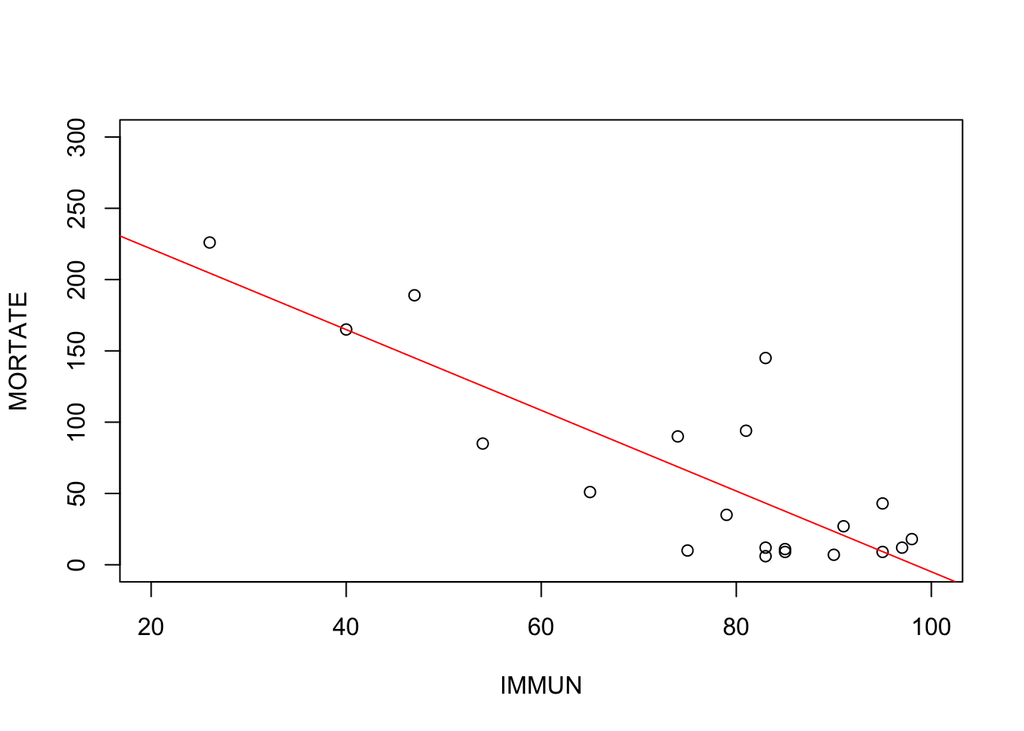

```r
## Build plot
plot(dptmort$immun,
     dptmort$mortate,
     ylab="MORTATE",
     xlab="IMMUN",
     ylim=c(0,300),
     xlim=c(20, 100))
abline(model, col = 'red')
```

**Interpretation:**  
The output from lm() function is divided into several different parts:

- The first table of output is the Residuals.
- The second table from the output describes the parameter estimates. This table lists the estimate for the intercept, $\alpha$ (sometimes called $\beta_0$)  and the estimate for the slope of the independent variable, $\beta$ (sometimes called $\beta_1$). The parameter estimate $\pm t_{0.975,n-2}*(standard error of estimate)$ will give a 95% confidence interval for that parameter. The t-test and associated p-value test the null hypothesis that the parameter estimate is equal to zero. The t-statistic can be calculated by taking the parameter estimate and dividing it by the standard error for that estimate. Since both of the parameters had p values less than 0.05, we can reject the null hypothesis that they are 0. In other words, these are significant terms and should be used in our model.
- The F-statistic gives a test statistic and p-value associated with a test of the hypothesis that the model explains a significant portion of the variation in the dependent variable. To calculate the F-statistic, divide the mean square for the model by the mean square error. Logically, as the mean square error decreases and the model mean square increases, the better the independent variable explains the variability in the dependent variable. In other words, a significant p-value indicates that the model explains a significant proportion of the variation in the outcome.
- The R-squared term equals the model sum of squares divided by the total sum of squares or the Pearson correlation coefficient, r, squared. $R^2$, also known as the coefficient of determination, represents the proportion of variability among observed values of y that is explained by the model. This is a value between 0 and 1 (but it’s not a probability; it’s a proportion). An $R^2$ value closer to 1 is considered good.

The model resulting from this analysis is **mortate = 278.2601 - 2.8317 immun**. Thus, for one increase in immunizations, under age 5 mortality rate will decrease by 2.83 deaths/year. The intercept, 278.26, is the value of under age 5 mortality rate when **immun = 0**. This may (may not) make sense; it will depend on the context or biology involved.

**Note:** this line should not be used to extrapolate, i.e. to predict y based on x values beyond the range of the observed data.

The following plot was created using the abline() function. To print the graph, all you need to do is feed this function the variable that you set your model to.

**Confidence and Prediction Intervals:** Recall that confidence intervals are statements about computed statistics, i.e., possible or reasonable values for parameters (mean, variance, slope, etc.) we are estimating. That is confidence intervals give us a choice of possible values, rather than the single best point estimate. When used to estimate the expected value (or mean) of y for a give x in the target population, the Confidence Interval uses the standard error ($\frac{\sigma}{sqrt[n]}$)  to determine the range of points that estimate this mean.

Prediction intervals, on the other hand, provide a range of likely values for the prediction of a single value for y for a given x value. Prediction intervals uses the standard deviation ($\sigma$) to determine the range of points that estimate the expected value of y. Which intervals do you think will be wider?

```r
## Note, that we have to specify the argument interval=”confidence” to get
# the upper and lower confidence intervals.
predict(model, interval="confidence")
```

```
##            fit         lwr       upr
## 1  164.9913665 125.9939089 203.98882
## 2  125.3473133  97.2920734 153.40255
## 3   37.5640527  17.3143969  57.81371
## 4    9.2468718 -16.3479311  34.84167
## 5   48.8909250  29.8616666  67.92018
## 6  204.6354197 153.5954082 255.67543
## 7   23.4054622   0.8175652  45.99336
## 8    9.2468718 -16.3479311  34.84167
## 9   43.2274888  23.6697969  62.78518
## 10  43.2274888  23.6697969  62.78518
## 11  37.5640527  17.3143969  57.81371
## 12  43.2274888  23.6697969  62.78518
## 13  94.1984144  72.8313013 115.56553
## 14   0.7517176 -26.8795378  28.38297
## 15 145.1693399 111.8507699 178.48791
## 16  68.7129516  50.0826538  87.34325
## 17  65.8812335  47.3375440  84.42492
## 18   3.5834356 -23.3529123  30.51978
## 19  54.5543612  35.8761212  73.23260
## 20  20.5737442  -2.5695477  43.71704
```

**Plotting The Intervals:**

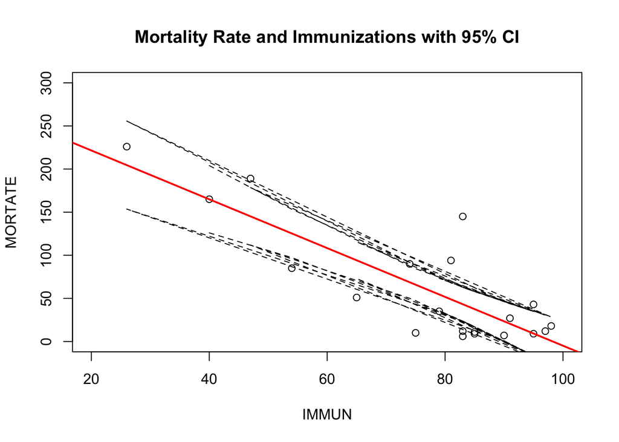

```r
## To graph the 95% confidence intervals, we are going to use the predict()
#  function that we used above and will set it to the variable “a”.
a <- predict(model, interval="confidence")

## Before plotting the lines, we need to call our scatterplot again. AS well
#  as re-fit our regression line.
plot(dptmort$immun, dptmort$mortate,
     ylab="MORTATE",
     xlab="IMMUN",
     ylim=c(0,300),
     xlim=c(20, 100),
     main= "Mortality Rate and Immunizations with 95% CI")
abline(model, lwd=2,col="red")

## Then we are going to use that variable to create to lines to overlay on the
#  graph. One for the upper confidence level and one for the lower
#  confidence level.
lines(dptmort$immun, a[,2], lty=2)
lines(dptmort$immun, a[,3], lty=2)
```

**Plotting The Predicted And Observed Values:**

```r
## To plot the predicted and observed values we need to install and load the
#  lattice package, by using the require() function.
suppressMessages(library(lattice))

## Then we are going to create a dataset to hold both the observed and fitted
#  values of mortality. After we have created this dataset, we are going to
#  add a column for the values of immunizations. The first 6 rows of the dataset
#  will be printed so you can confirm what we did.
res <- stack(data.frame(Observed = dptmort$mortate,
                        Predicted = fitted(model)))
res <- cbind(res, x = rep(dptmort$immun, 2))
head(res)
```

```
##   values      ind  x
## 1    165 Observed 40
## 2     85 Observed 54
## 3      9 Observed 85
## 4     43 Observed 95
## 5     94 Observed 81
## 6    226 Observed 26
```

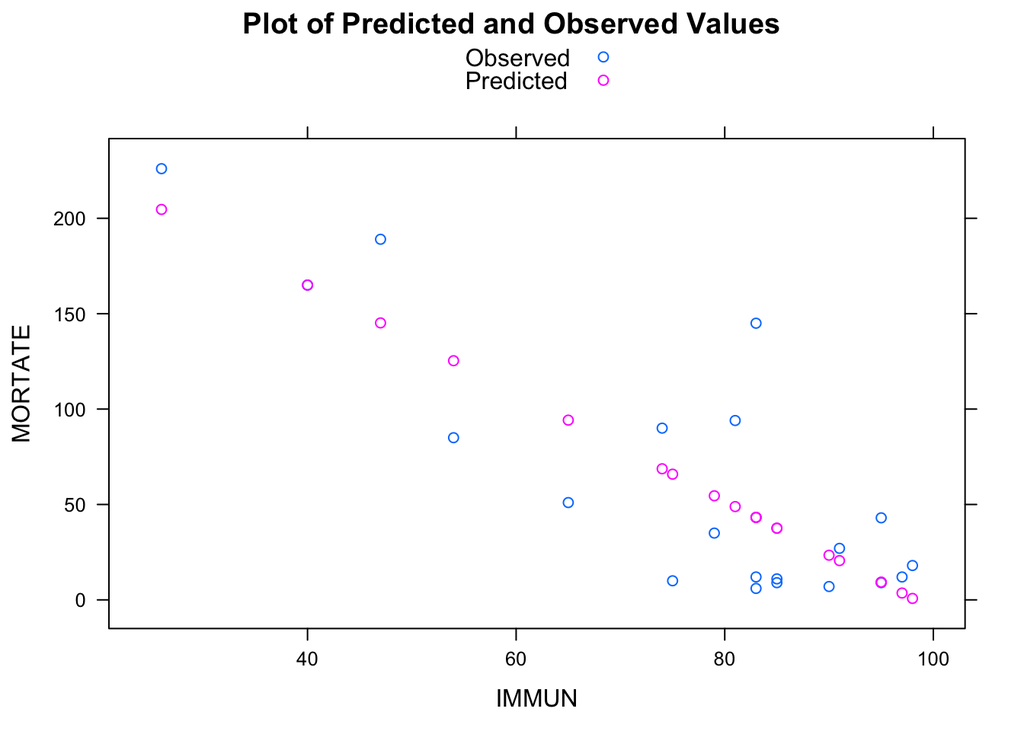

```r
## Then, we are going to graph the predicted and observed values together.
xyplot(values ~ x,
       data = res,
       group = ind,
       auto.key = TRUE,
       main="Plot of Predicted and Observed Values",
       xlab="IMMUN",
       ylab="MORTATE")
```